# COVID-19 Analysis

2023-08-22

## The Data

This data consists of COVID-19 cases and deaths both globally and in the U.S.A. This is time series data that shows the cases and deaths over time. Included in the U.S. data is population by state and the global data will be joined with country population.

The data is available here: https://github.com/CSSEGISandData/COVID-19/tree/master/csse_covid_19_data/csse_covid_19_time_series

## Purpose

This report will be examining this data and comparing the impact score (defined by death/cases*100) of COVID-19 by both U.S. State and Country to see where COVID-19 had the highest proportion of deaths to cases.

### Load the data

```r
# Load the dataset
get_url <- "https://raw.githubusercontent.com/CSSEGISandData/COVID-19/master/csse_covid_19_data/csse_covid_19_time_series/"
file_names <- c("time_series_covid19_confirmed_global.csv",
                "time_series_covid19_deaths_global.csv",
                "time_series_covid19_confirmed_US.csv",
                "time_series_covid19_deaths_US.csv")
urls <- str_c(get_url, file_names)

global_cases <- read_csv(urls[1])
global_deaths <- read_csv(urls[2])
US_cases <- read_csv(urls[3])
US_deaths <- read_csv(urls[4])
```

```r
# Get population data for global
uid_lookup_url <- "https://raw.githubusercontent.com/CSSEGISandData/COVID-19/master/csse_covid_19_data/UID_ISO_FIPS_LookUp_Table.csv"

# Load US states shapefile data
us_states <- st_read("https://raw.githubusercontent.com/PublicaMundi/MappingAPI/master/data/geojson/us-states.json", quiet = TRUE)
```

### Clean and transform

Since we are looking at the both by U.S. State and by country we want the data structures to look as similar as possible.

Here will be cleaning both and doing the necessary transformation so we can compare the two.

[output not shown]

```
## # A tibble: 63,216 × 7
##    Province_State date       cases deaths deaths_per_mill impact Population
##    <chr>          <date>     <dbl>  <dbl>           <dbl>  <dbl>      <dbl>
##  1 Alabama        2020-03-11     3      0               0      0     534756
##  2 Alabama        2020-03-12     4      0               0      0     907665
##  3 Alabama        2020-03-13     8      0               0      0    1647447
##  4 Alabama        2020-03-14    15      0               0      0    1647447
##  5 Alabama        2020-03-15    28      0               0      0    2252925
##  6 Alabama        2020-03-16    36      0               0      0    2252925
##  7 Alabama        2020-03-17    51      0               0      0    2456042
##  8 Alabama        2020-03-18    61      0               0      0    2536020
##  9 Alabama        2020-03-19    88      0               0      0    3129773
## 10 Alabama        2020-03-20   115      0               0      0    3333968
## # ℹ 63,206 more rows
```

```
## # A tibble: 214,113 × 7
##    Country_Region date       cases deaths deaths_per_mill impact Population
##    <chr>          <date>     <dbl>  <dbl>           <dbl>  <dbl>      <dbl>
##  1 Afghanistan    2020-02-24     5      0               0      0   38928341
##  2 Afghanistan    2020-02-25     5      0               0      0   38928341
##  3 Afghanistan    2020-02-26     5      0               0      0   38928341
##  4 Afghanistan    2020-02-27     5      0               0      0   38928341
##  5 Afghanistan    2020-02-28     5      0               0      0   38928341
##  6 Afghanistan    2020-02-29     5      0               0      0   38928341
##  7 Afghanistan    2020-03-01     5      0               0      0   38928341
##  8 Afghanistan    2020-03-02     5      0               0      0   38928341
##  9 Afghanistan    2020-03-03     5      0               0      0   38928341
## 10 Afghanistan    2020-03-04     5      0               0      0   38928341
## # ℹ 214,103 more rows
```

Now that we have data structures that look comparable lets examine it in a more digestable way.

### Visualizations and Analysis

First lets take a look at the total cases and deaths globally and then in the U.S.A.

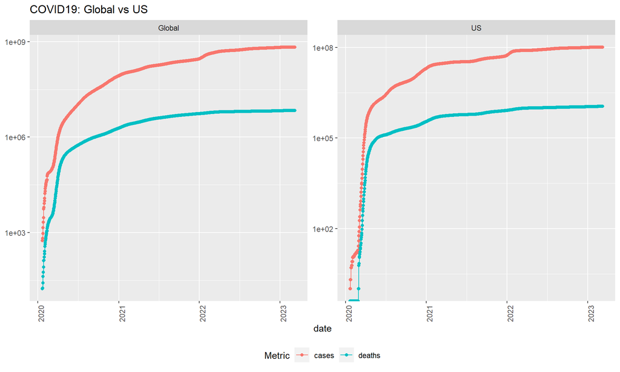

The trend between the two data sets seems to be similar. Lets see how they each do when considering the previously defined impact score.

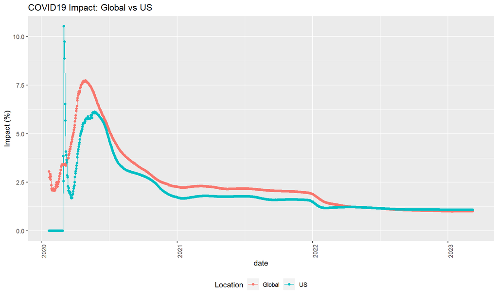

The impacts seem to again follow a similar trend. Lets see how the global impact relates to the U.S. impact using a linear regression model.

```
##
## Call:
## lm(formula = US_impact ~ global_impact, data = merged_impact_data)
##
## Residuals:
##     Min      1Q  Median      3Q     Max
## -2.6987 -0.0727  0.0537  0.1482  7.8267
##
## Coefficients:
##               Estimate Std. Error t value Pr(>|t|)
## (Intercept)    0.18358    0.03496   5.251  1.8e-07 ***
## global_impact  0.73593    0.01217  60.468  < 2e-16 ***
## ---
## Signif. codes:  0 '***' 0.001 '**' 0.01 '*' 0.05 '.' 0.1 ' ' 1
##
## Residual standard error: 0.6509 on 1141 degrees of freedom
## Multiple R-squared:  0.7622, Adjusted R-squared:  0.762
## F-statistic:  3656 on 1 and 1141 DF,  p-value: < 2.2e-16
```

This results, not surprisingly, suggest that there is a strong correlation between the global impact and the U.S. impact.

Lets do a little validation.

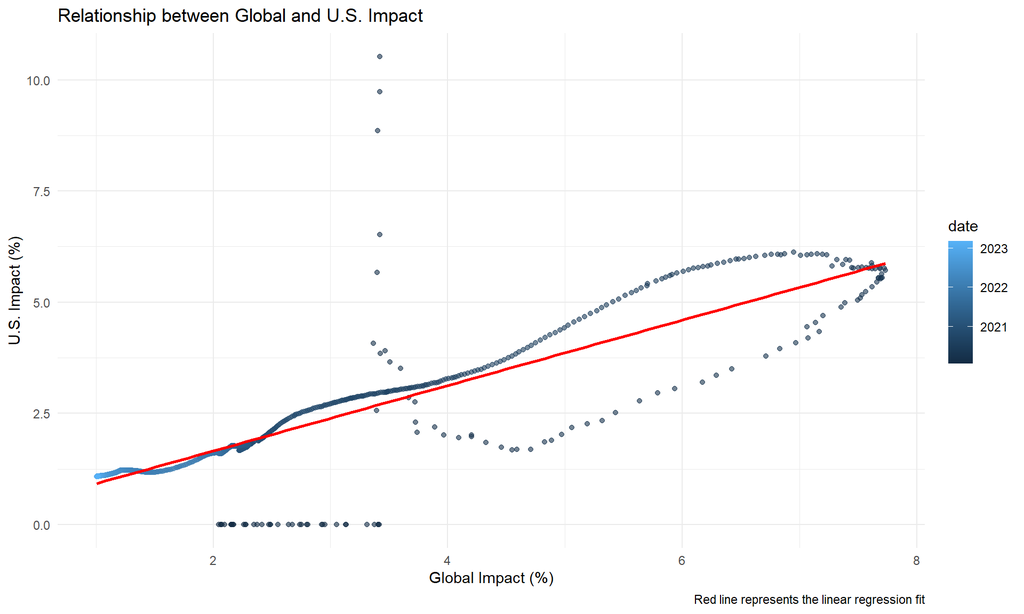

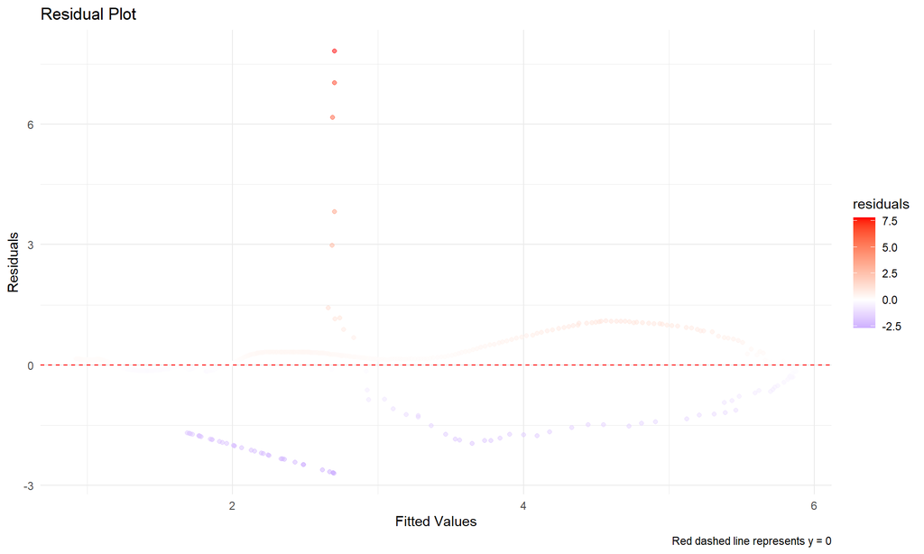

```
##
##  studentized Breusch-Pagan test
##
## data:  model
## BP = 17.11, df = 1, p-value = 3.527e-05
```

Given the close correlation lets use the average impact score to determine how the U.S. did compared to the whole world.

```r
# Calculate the average impact scores for both US and global data
avg_US_impact <- mean(US_totals$impact, na.rm = TRUE)
avg_global_impact <- mean(global_by_country$impact, na.rm = TRUE)

# Compare the average US impact to the average global impact
comparison <- ifelse(avg_US_impact < avg_global_impact, 'better', 'worse')

list(avg_US_impact = avg_US_impact, avg_global_impact = avg_global_impact, comparison = comparison)
```

```
## $avg_US_impact
## [1] 1.948206
##
## $avg_global_impact
## [1] 2.97612
##
## $comparison
## [1] "better"
```

So the U.S. appears to have done at leasts a little better.

Just for fun lets look at how each state compares by impact score using a heatmap.

[interactive chart not shown]

### Issues

1. While John Hopkins is a reputable source for data there can be bias introduced based on the reporting of cases and deaths.
2. In the context of a pandemic using past data to try and predict anything is going to be problematic at best without accounting for how various factors such as pandemic response has changed over time.
3. Defining impact score as death/cases*100 is simplistic and leaves out things such as hospitalizations and long-term health effects.
4. No where are external factors such as healthcare infrastructure, public health guidelines, and socio-economic conditions.
5. The global data set was too large to create a heatmap given local hardware limitations and the leaflet library’s ability to hand large data.